# Optimal Treatment Analysis

## Outcome Variable

**Outcome Variable:** whz

## Predictor Variables

**Intervention Variable:** exclfeed36

**Adjustment Set:**

- arm
- sex
- brthmon
- W_mage
- meducyrs
- feducyrs
- hhwealth_quart
- hfoodsec
- W_mhtcm
- W_mwtkg
- W_mbmi
- vagbrth
- W_gagebrth
- W_birthwt
- W_birthlen
- W_nrooms
- W_nchldlt5
- month
- W_parity
- impfloor
- impsan
- safeh20
- delta_W_mage
- delta_meducyrs
- delta_feducyrs
- delta_hhwealth_quart
- delta_hfoodsec
- delta_W_mhtcm
- delta_W_mwtkg
- delta_W_mbmi
- delta_vagbrth
- delta_W_gagebrth
- delta_W_birthwt
- delta_W_birthlen
- delta_W_nrooms
- delta_W_nchldlt5
- delta_month
- delta_W_parity
- delta_impfloor
- delta_impsan
- delta_safeh20

## Stratifying Variables

The analysis was stratified on these variable(s):

- agecat
- studyid
- country

## Data Summary

| agecat | studyid | country | exclfeed36 | n_cell | n |
| --- | --- | --- | --- | --- | --- |
| Birth | CMC-V-BCS-2002 | INDIA | 1 | 3 | 3 |
| Birth | CMC-V-BCS-2002 | INDIA | 0 | 0 | 3 |
| Birth | EE | PAKISTAN | 1 | 2 | 6 |
| Birth | EE | PAKISTAN | 0 | 4 | 6 |
| Birth | GMS-Nepal | NEPAL | 1 | 396 | 491 |
| Birth | GMS-Nepal | NEPAL | 0 | 95 | 491 |
| Birth | IRC | INDIA | 1 | 0 | 3 |
| Birth | IRC | INDIA | 0 | 3 | 3 |
| Birth | JiVitA-3 | BANGLADESH | 1 | 6736 | 8619 |
| Birth | JiVitA-3 | BANGLADESH | 0 | 1883 | 8619 |
| Birth | JiVitA-4 | BANGLADESH | 1 | 1711 | 2128 |
| Birth | JiVitA-4 | BANGLADESH | 0 | 417 | 2128 |
| Birth | Keneba | GAMBIA | 1 | 343 | 1192 |
| Birth | Keneba | GAMBIA | 0 | 849 | 1192 |
| Birth | MAL-ED | BANGLADESH | 1 | 31 | 208 |
| Birth | MAL-ED | BANGLADESH | 0 | 177 | 208 |
| Birth | MAL-ED | BRAZIL | 1 | 4 | 62 |
| Birth | MAL-ED | BRAZIL | 0 | 58 | 62 |
| Birth | MAL-ED | INDIA | 1 | 1 | 40 |
| Birth | MAL-ED | INDIA | 0 | 39 | 40 |
| Birth | MAL-ED | NEPAL | 1 | 0 | 25 |
| Birth | MAL-ED | NEPAL | 0 | 25 | 25 |
| Birth | MAL-ED | PERU | 1 | 5 | 218 |
| Birth | MAL-ED | PERU | 0 | 213 | 218 |
| Birth | MAL-ED | SOUTH AFRICA | 1 | 1 | 104 |
| Birth | MAL-ED | SOUTH AFRICA | 0 | 103 | 104 |
| Birth | MAL-ED | TANZANIA, UNITED REPUBLIC OF | 1 | 0 | 111 |
| Birth | MAL-ED | TANZANIA, UNITED REPUBLIC OF | 0 | 111 | 111 |
| Birth | PROVIDE | BANGLADESH | 1 | 115 | 483 |
| Birth | PROVIDE | BANGLADESH | 0 | 368 | 483 |

[output cut: 66 more lines]

The following strata were considered:

- agecat: 24 months, studyid: CMC-V-BCS-2002, country: INDIA
- agecat: 24 months, studyid: EE, country: PAKISTAN
- agecat: 24 months, studyid: GMS-Nepal, country: NEPAL
- agecat: 24 months, studyid: IRC, country: INDIA
- agecat: 24 months, studyid: JiVitA-3, country: BANGLADESH
- agecat: 24 months, studyid: JiVitA-4, country: BANGLADESH
- agecat: 24 months, studyid: Keneba, country: GAMBIA
- agecat: 24 months, studyid: LCNI-5, country: MALAWI
- agecat: 24 months, studyid: MAL-ED, country: BANGLADESH
- agecat: 24 months, studyid: MAL-ED, country: BRAZIL
- agecat: 24 months, studyid: MAL-ED, country: INDIA
- agecat: 24 months, studyid: MAL-ED, country: NEPAL
- agecat: 24 months, studyid: MAL-ED, country: PERU
- agecat: 24 months, studyid: MAL-ED, country: SOUTH AFRICA
- agecat: 24 months, studyid: MAL-ED, country: TANZANIA, UNITED REPUBLIC OF
- agecat: 24 months, studyid: PROVIDE, country: BANGLADESH
- agecat: 6 months, studyid: CMC-V-BCS-2002, country: INDIA
- agecat: 6 months, studyid: EE, country: PAKISTAN
- agecat: 6 months, studyid: GMS-Nepal, country: NEPAL
- agecat: 6 months, studyid: IRC, country: INDIA
- agecat: 6 months, studyid: JiVitA-3, country: BANGLADESH
- agecat: 6 months, studyid: JiVitA-4, country: BANGLADESH
- agecat: 6 months, studyid: Keneba, country: GAMBIA
- agecat: 6 months, studyid: LCNI-5, country: MALAWI
- agecat: 6 months, studyid: MAL-ED, country: BANGLADESH
- agecat: 6 months, studyid: MAL-ED, country: BRAZIL
- agecat: 6 months, studyid: MAL-ED, country: INDIA
- agecat: 6 months, studyid: MAL-ED, country: NEPAL
- agecat: 6 months, studyid: MAL-ED, country: PERU
- agecat: 6 months, studyid: MAL-ED, country: SOUTH AFRICA
- agecat: 6 months, studyid: MAL-ED, country: TANZANIA, UNITED REPUBLIC OF
- agecat: 6 months, studyid: PROVIDE, country: BANGLADESH
- agecat: 6 months, studyid: SAS-FoodSuppl, country: INDIA
- agecat: Birth, studyid: CMC-V-BCS-2002, country: INDIA
- agecat: Birth, studyid: EE, country: PAKISTAN
- agecat: Birth, studyid: GMS-Nepal, country: NEPAL
- agecat: Birth, studyid: IRC, country: INDIA
- agecat: Birth, studyid: JiVitA-3, country: BANGLADESH
- agecat: Birth, studyid: JiVitA-4, country: BANGLADESH
- agecat: Birth, studyid: Keneba, country: GAMBIA
- agecat: Birth, studyid: MAL-ED, country: BANGLADESH
- agecat: Birth, studyid: MAL-ED, country: BRAZIL
- agecat: Birth, studyid: MAL-ED, country: INDIA
- agecat: Birth, studyid: MAL-ED, country: NEPAL
- agecat: Birth, studyid: MAL-ED, country: PERU
- agecat: Birth, studyid: MAL-ED, country: SOUTH AFRICA
- agecat: Birth, studyid: MAL-ED, country: TANZANIA, UNITED REPUBLIC OF
- agecat: Birth, studyid: PROVIDE, country: BANGLADESH

### Dropped Strata

Some strata were dropped due to rare outcomes:

- agecat: Birth, studyid: CMC-V-BCS-2002, country: INDIA
- agecat: Birth, studyid: EE, country: PAKISTAN
- agecat: Birth, studyid: IRC, country: INDIA
- agecat: Birth, studyid: MAL-ED, country: BRAZIL
- agecat: Birth, studyid: MAL-ED, country: INDIA
- agecat: Birth, studyid: MAL-ED, country: NEPAL
- agecat: Birth, studyid: MAL-ED, country: SOUTH AFRICA
- agecat: Birth, studyid: MAL-ED, country: TANZANIA, UNITED REPUBLIC OF
- agecat: 6 months, studyid: CMC-V-BCS-2002, country: INDIA
- agecat: 6 months, studyid: EE, country: PAKISTAN
- agecat: 6 months, studyid: IRC, country: INDIA
- agecat: 6 months, studyid: MAL-ED, country: NEPAL
- agecat: 6 months, studyid: MAL-ED, country: SOUTH AFRICA
- agecat: 6 months, studyid: MAL-ED, country: TANZANIA, UNITED REPUBLIC OF
- agecat: 6 months, studyid: SAS-FoodSuppl, country: INDIA
- agecat: 24 months, studyid: CMC-V-BCS-2002, country: INDIA
- agecat: 24 months, studyid: EE, country: PAKISTAN
- agecat: 24 months, studyid: IRC, country: INDIA
- agecat: 24 months, studyid: MAL-ED, country: NEPAL
- agecat: 24 months, studyid: MAL-ED, country: PERU
- agecat: 24 months, studyid: MAL-ED, country: SOUTH AFRICA
- agecat: 24 months, studyid: MAL-ED, country: TANZANIA, UNITED REPUBLIC OF

## Methods Detail

We’re interested in the causal parameters $E[Y_a]$ for all values of $a \in \mathcal{A}$. These parameters represent the mean outcome if, possibly contrary to fact, we intervened to set all units to have $A=a$. Under the randomization and positivity assumptions, these are identified by the statistical parameters $\psi_a=E_W[E_{Y|A,W}(Y|A=a,W)]$. In addition, we’re interested in the mean of $Y$, $E[Y]$ under no intervention (the observed mean). We will estimate these parameters by using SuperLearner to fit the relevant likelihood factors – $E_{Y|A,W}(Y|A=a,W)$ and $p(A=a|W)$, and then updating our likelihood fit using a joint TMLE.

For unadjusted analyses ($W=\{\}$), initial likelihoods were estimated using Lrnr_glm to estimate the simple $E(Y|A)$ and Lrnr_mean to estimate $p(A)$. For adjusted analyses, a small library containing Lrnr_glmnet, Lrnr_xgboost, and Lrnr_mean was used.

Having estimated these parameters, we will then use the delta method to estimate relative risks and attributable risks relative to a prespecified baseline level of $A$.

# Results Detail

## Results Plots

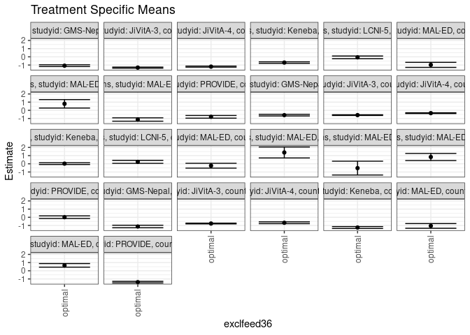

## Results Table

### Parameter: TSM

| agecat | studyid | country | intervention_level | baseline_level | estimate | ci_lower | ci_upper |
| --- | --- | --- | --- | --- | --- | --- | --- |
| Birth | GMS-Nepal | NEPAL | optimal | observed | -1.1261576 | -1.2808577 | -0.9714576 |
| Birth | JiVitA-3 | BANGLADESH | optimal | observed | -0.7627291 | -0.8109674 | -0.7144909 |
| Birth | JiVitA-4 | BANGLADESH | optimal | observed | -0.6694214 | -0.7805332 | -0.5583096 |
| Birth | Keneba | GAMBIA | optimal | observed | -1.2521760 | -1.3692947 | -1.1350574 |
| Birth | MAL-ED | BANGLADESH | optimal | observed | -1.0550024 | -1.3423754 | -0.7676293 |
| Birth | MAL-ED | PERU | optimal | observed | 0.6612074 | 0.4387725 | 0.8836422 |
| Birth | PROVIDE | BANGLADESH | optimal | observed | -1.3906172 | -1.4871112 | -1.2941232 |
| 6 months | GMS-Nepal | NEPAL | optimal | observed | -0.5877604 | -0.6883944 | -0.4871264 |
| 6 months | JiVitA-3 | BANGLADESH | optimal | observed | -0.5852817 | -0.6257053 | -0.5448580 |
| 6 months | JiVitA-4 | BANGLADESH | optimal | observed | -0.3460028 | -0.3922188 | -0.2997867 |
| 6 months | Keneba | GAMBIA | optimal | observed | 0.0211601 | -0.0862474 | 0.1285676 |
| 6 months | LCNI-5 | MALAWI | optimal | observed | 0.2393132 | 0.0560026 | 0.4226237 |
| 6 months | MAL-ED | BANGLADESH | optimal | observed | -0.2334868 | -0.5280175 | 0.0610440 |
| 6 months | MAL-ED | BRAZIL | optimal | observed | 1.3826969 | 0.7133006 | 2.0520932 |
| 6 months | MAL-ED | INDIA | optimal | observed | -0.5266612 | -1.3695779 | 0.3162555 |
| 6 months | MAL-ED | PERU | optimal | observed | 0.8323006 | 0.3982946 | 1.2663067 |
| 6 months | PROVIDE | BANGLADESH | optimal | observed | 0.0104949 | -0.1510569 | 0.1720466 |
| 24 months | GMS-Nepal | NEPAL | optimal | observed | -1.0813153 | -1.1900704 | -0.9725602 |
| 24 months | JiVitA-3 | BANGLADESH | optimal | observed | -1.3148329 | -1.3798091 | -1.2498568 |
| 24 months | JiVitA-4 | BANGLADESH | optimal | observed | -1.1971448 | -1.2616410 | -1.1326487 |
| 24 months | Keneba | GAMBIA | optimal | observed | -0.7011770 | -0.7947593 | -0.6075946 |
| 24 months | LCNI-5 | MALAWI | optimal | observed | -0.0628826 | -0.2244671 | 0.0987019 |
| 24 months | MAL-ED | BANGLADESH | optimal | observed | -0.9814997 | -1.2887948 | -0.6742047 |
| 24 months | MAL-ED | BRAZIL | optimal | observed | 0.7946415 | 0.2779819 | 1.3113011 |
| 24 months | MAL-ED | INDIA | optimal | observed | -1.1243918 | -1.3289640 | -0.9198197 |
| 24 months | PROVIDE | BANGLADESH | optimal | observed | -0.7944135 | -0.9593522 | -0.6294749 |

### Parameter: E(Y)

| agecat | studyid | country | intervention_level | baseline_level | estimate | ci_lower | ci_upper |
| --- | --- | --- | --- | --- | --- | --- | --- |
| Birth | GMS-Nepal | NEPAL | observed | observed | -1.1085743 | -1.2077878 | -1.0093609 |
| Birth | JiVitA-3 | BANGLADESH | observed | observed | -0.7892308 | -0.8133344 | -0.7651272 |
| Birth | JiVitA-4 | BANGLADESH | observed | observed | -0.7018985 | -0.7560164 | -0.6477806 |
| Birth | Keneba | GAMBIA | observed | observed | -1.2752643 | -1.3442810 | -1.2062476 |
| Birth | MAL-ED | BANGLADESH | observed | observed | -0.9480769 | -1.0934921 | -0.8026617 |
| Birth | MAL-ED | PERU | observed | observed | -0.0458257 | -0.1696487 | 0.0779973 |
| Birth | PROVIDE | BANGLADESH | observed | observed | -1.2966874 | -1.3774293 | -1.2159454 |
| 6 months | GMS-Nepal | NEPAL | observed | observed | -0.6001075 | -0.6890924 | -0.5111227 |
| 6 months | JiVitA-3 | BANGLADESH | observed | observed | -0.5995202 | -0.6251579 | -0.5738825 |
| 6 months | JiVitA-4 | BANGLADESH | observed | observed | -0.3960017 | -0.4356255 | -0.3563778 |
| 6 months | Keneba | GAMBIA | observed | observed | -0.2009461 | -0.2562412 | -0.1456509 |
| 6 months | LCNI-5 | MALAWI | observed | observed | 0.3925000 | 0.2735307 | 0.5114693 |
| 6 months | MAL-ED | BANGLADESH | observed | observed | -0.1354583 | -0.2647102 | -0.0062065 |
| 6 months | MAL-ED | BRAZIL | observed | observed | 0.9720774 | 0.8078144 | 1.1363403 |
| 6 months | MAL-ED | INDIA | observed | observed | -0.7161910 | -0.8437667 | -0.5886153 |
| 6 months | MAL-ED | PERU | observed | observed | 1.0511642 | 0.9291821 | 1.1731463 |
| 6 months | PROVIDE | BANGLADESH | observed | observed | -0.1990907 | -0.2817968 | -0.1163845 |
| 24 months | GMS-Nepal | NEPAL | observed | observed | -1.1236255 | -1.2167712 | -1.0304797 |
| 24 months | JiVitA-3 | BANGLADESH | observed | observed | -1.3352235 | -1.3688736 | -1.3015735 |
| 24 months | JiVitA-4 | BANGLADESH | observed | observed | -1.2344089 | -1.2708428 | -1.1979750 |
| 24 months | Keneba | GAMBIA | observed | observed | -0.7973955 | -0.8498696 | -0.7449213 |
| 24 months | LCNI-5 | MALAWI | observed | observed | -0.0770652 | -0.2204213 | 0.0662909 |
| 24 months | MAL-ED | BANGLADESH | observed | observed | -0.8192925 | -0.9412667 | -0.6973182 |
| 24 months | MAL-ED | BRAZIL | observed | observed | 0.4626233 | 0.2567495 | 0.6684971 |
| 24 months | MAL-ED | INDIA | observed | observed | -0.9581250 | -1.0746982 | -0.8415518 |
| 24 months | PROVIDE | BANGLADESH | observed | observed | -0.8945581 | -0.9774087 | -0.8117074 |

### Parameter: PAR

| agecat | studyid | country | intervention_level | baseline_level | estimate | ci_lower | ci_upper |
| --- | --- | --- | --- | --- | --- | --- | --- |
| Birth | GMS-Nepal | NEPAL | optimal | observed | 0.0175833 | -0.1028798 | 0.1380464 |
| Birth | JiVitA-3 | BANGLADESH | optimal | observed | -0.0265016 | -0.0677877 | 0.0147844 |
| Birth | JiVitA-4 | BANGLADESH | optimal | observed | -0.0324771 | -0.1153390 | 0.0503849 |
| Birth | Keneba | GAMBIA | optimal | observed | -0.0230882 | -0.1156367 | 0.0694602 |
| Birth | MAL-ED | BANGLADESH | optimal | observed | 0.1069254 | -0.1630210 | 0.3768718 |
| Birth | MAL-ED | PERU | optimal | observed | -0.7070331 | -0.9573168 | -0.4567494 |
| Birth | PROVIDE | BANGLADESH | optimal | observed | 0.0939298 | 0.0303954 | 0.1574643 |
| 6 months | GMS-Nepal | NEPAL | optimal | observed | -0.0123471 | -0.0582379 | 0.0335437 |
| 6 months | JiVitA-3 | BANGLADESH | optimal | observed | -0.0142386 | -0.0464425 | 0.0179654 |
| 6 months | JiVitA-4 | BANGLADESH | optimal | observed | -0.0499989 | -0.0720997 | -0.0278981 |
| 6 months | Keneba | GAMBIA | optimal | observed | -0.2221061 | -0.3120342 | -0.1321780 |
| 6 months | LCNI-5 | MALAWI | optimal | observed | 0.1531868 | 0.0147604 | 0.2916132 |
| 6 months | MAL-ED | BANGLADESH | optimal | observed | 0.0980285 | -0.1622375 | 0.3582944 |
| 6 months | MAL-ED | BRAZIL | optimal | observed | -0.4106195 | -1.0604295 | 0.2391904 |
| 6 months | MAL-ED | INDIA | optimal | observed | -0.1895298 | -1.0136002 | 0.6345407 |
| 6 months | MAL-ED | PERU | optimal | observed | 0.2188636 | -0.2188627 | 0.6565899 |
| 6 months | PROVIDE | BANGLADESH | optimal | observed | -0.2095855 | -0.3526641 | -0.0665069 |
| 24 months | GMS-Nepal | NEPAL | optimal | observed | -0.0423102 | -0.1084908 | 0.0238705 |
| 24 months | JiVitA-3 | BANGLADESH | optimal | observed | -0.0203906 | -0.0763123 | 0.0355311 |
| 24 months | JiVitA-4 | BANGLADESH | optimal | observed | -0.0372641 | -0.0896426 | 0.0151144 |
| 24 months | Keneba | GAMBIA | optimal | observed | -0.0962185 | -0.1740301 | -0.0184069 |
| 24 months | LCNI-5 | MALAWI | optimal | observed | -0.0141827 | -0.0772455 | 0.0488802 |
| 24 months | MAL-ED | BANGLADESH | optimal | observed | 0.1622073 | -0.1219882 | 0.4464028 |
| 24 months | MAL-ED | BRAZIL | optimal | observed | -0.3320182 | -0.8050056 | 0.1409691 |
| 24 months | MAL-ED | INDIA | optimal | observed | 0.1662668 | -0.0160806 | 0.3486142 |
| 24 months | PROVIDE | BANGLADESH | optimal | observed | -0.1001445 | -0.2442907 | 0.0440017 |